# TimeSeriesForecasting

```python
!pip install statsforecast utilsforecast
```

[output not shown]

```python
import numpy as np
import pandas as pd
import matplotlib.pyplot as plt

from utilsforecast.plotting import plot_series
from utilsforecast.evaluation import evaluate
from utilsforecast.losses import *

import warnings
warnings.filterwarnings("ignore")
```

```python
data = pd.read_csv("daily_sales_french_bakery.csv")
```

```python
data.drop(['unit_price'], axis=1, inplace=True)
```

```python
df = data.copy()
df.head(10)
```

|  | unique_id | ds | y |
| --- | --- | --- | --- |
| 0 | 12 MACARON | 2022-07-13 | 10.0 |
| 1 | 12 MACARON | 2022-07-14 | 0.0 |
| 2 | 12 MACARON | 2022-07-15 | 0.0 |
| 3 | 12 MACARON | 2022-07-16 | 10.0 |
| 4 | 12 MACARON | 2022-07-17 | 30.0 |
| 5 | 12 MACARON | 2022-07-18 | 0.0 |
| 6 | 12 MACARON | 2022-07-19 | 10.0 |
| 7 | 12 MACARON | 2022-07-20 | 0.0 |
| 8 | 12 MACARON | 2022-07-21 | 10.0 |
| 9 | 12 MACARON | 2022-07-22 | 0.0 |

```python
df.shape
```

```
(57046, 3)
```

```python
df.info()
```

```
<class 'pandas.core.frame.DataFrame'>
RangeIndex: 57046 entries, 0 to 57045
Data columns (total 3 columns):
 #   Column     Non-Null Count  Dtype
---  ------     --------------  -----
 0   unique_id  57046 non-null  object
 1   ds         57046 non-null  object
 2   y          57046 non-null  float64
dtypes: float64(1), object(2)
memory usage: 1.3+ MB
```

```python
df['ds'] = pd.to_datetime(df['ds'], format='%Y-%m-%d')
```

```python
df.describe()
```

|  | ds | y |
| --- | --- | --- |
| count | 57046 | 57046.000000 |
| mean | 2021-11-18 13:24:30.770956544 | 9.792814 |
| min | 2021-01-02 00:00:00 | 0.000000 |
| 25% | 2021-06-25 00:00:00 | 0.000000 |
| 50% | 2021-11-17 00:00:00 | 0.900000 |
| 75% | 2022-04-17 00:00:00 | 8.000000 |
| max | 2022-09-30 00:00:00 | 919.100000 |
| std | NaN | 32.327068 |

```python
df.head()
```

|  | unique_id | ds | y |
| --- | --- | --- | --- |
| 0 | 12 MACARON | 2022-07-13 | 10.0 |
| 1 | 12 MACARON | 2022-07-14 | 0.0 |
| 2 | 12 MACARON | 2022-07-15 | 0.0 |
| 3 | 12 MACARON | 2022-07-16 | 10.0 |
| 4 | 12 MACARON | 2022-07-17 | 30.0 |

```python
df.info()
```

```
<class 'pandas.core.frame.DataFrame'>
RangeIndex: 57046 entries, 0 to 57045
Data columns (total 3 columns):
 #   Column     Non-Null Count  Dtype
---  ------     --------------  -----
 0   unique_id  57046 non-null  object
 1   ds         57046 non-null  datetime64[ns]
 2   y          57046 non-null  float64
dtypes: datetime64[ns](1), float64(1), object(1)
memory usage: 1.3+ MB
```

```python
df['unique_id'].nunique()
```

```
148
```

```python
df['unique_id'].unique()
```

```
array(['12 MACARON', 'ARMORICAIN', 'ARTICLE 295', 'BAGUETTE',
       'BAGUETTE APERO', 'BAGUETTE GRAINE', 'BANETTE', 'BANETTINE',
       'BOISSON 33CL', 'BOTTEREAU', 'BOULE 200G', 'BOULE 400G',
       'BOULE POLKA', 'BRIOCHE', 'BRIOCHE DE NOEL', 'BRIOCHETTE',
       'BROWNIES', 'BUCHE 4PERS', 'BUCHE 6PERS', 'BUCHE 8PERS',
       'CAFE OU EAU', 'CAKE', 'CAMPAGNE', 'CARAMEL NOIX',
       'CEREAL BAGUETTE', 'CHAUSSON AUX POMMES', 'CHOCOLAT',
       'CHOU CHANTILLY', 'COMPLET', 'COOKIE', 'COUPE', 'CROISSANT',
       'CROISSANT AMANDES', 'CRUMBLE', 'CRUMBLECARAMEL OU PISTAE',
       'DELICETROPICAL', 'DEMI BAGUETTE', 'DEMI PAIN', 'DIVERS BOISSONS',
       'DIVERS BOULANGERIE', 'DIVERS CONFISERIE', 'DIVERS PATISSERIE',
       'DIVERS SANDWICHS', 'DIVERS VIENNOISERIE', 'DOUCEUR D HIVER',
       'ECLAIR', 'ECLAIR FRAISE PISTACHE', 'ENTREMETS', 'FICELLE',
       'FINANCIER', 'FINANCIER X5', 'FLAN', 'FLAN ABRICOT',
       'FONDANT CHOCOLAT', 'FORMULE PATE', 'FORMULE PLAT PREPARE',
       'FORMULE SANDWICH', 'FRAISIER', 'FRAMBOISIER', 'GACHE',
       'GAL FRANGIPANE 4P', 'GAL FRANGIPANE 6P', 'GAL POIRE CHOCO 4P',
       'GAL POIRE CHOCO 6P', 'GAL POMME 4P', 'GAL POMME 6P',
       'GALETTE 8 PERS', 'GD FAR BRETON', 'GD KOUIGN AMANN', 'GD NANTAIS',
       'GD PLATEAU SALE', 'GRAND FAR BRETON', 'GRANDE SUCETTE',
       'GUERANDAIS', 'KOUIGN AMANN', 'MACARON', 'MERINGUE',
       'MILLES FEUILLES', 'MOISSON', 'NANTAIS', 'NID DE POULE',
       'NOIX JAPONAISE', 'PAILLE', 'PAIN', 'PAIN AU CHOCOLAT',
       'PAIN AUX RAISINS', 'PAIN BANETTE', 'PAIN CHOCO AMANDES',
       'PAIN DE MIE', 'PAIN GRAINES', 'PAIN NOIR', 'PAIN S/SEL',
       'PAIN SUISSE PEPITO', 'PALET BRETON', 'PALMIER', 'PARIS BREST',
       'PATES', 'PLAQUE TARTE 25P', 'PLAT', 'PLAT 6.50E', 'PLAT 7.00',
       'PLAT 7.60E', 'PLAT 8.30E', 'PLATPREPARE5.50', 'PLATPREPARE6.00',
       'PLATPREPARE6.50', 'PLATPREPARE7.00', 'PT NANTAIS',
       'PT PLATEAU SALE', 'QUIM BREAD', 'REDUCTION SUCREES 12',
       'REDUCTION SUCREES 24', 'RELIGIEUSE', 'ROYAL', 'ROYAL 4P',
       'ROYAL 6P', 'SABLE F  P', 'SACHET DE CROUTON',
       'SACHET DE VIENNOISERIE', 'SACHET VIENNOISERIE', 'SAND JB',
       'SAND JB EMMENTAL', 'SANDWICH COMPLET', 'SAVARIN', 'SEIGLE',
       'SPECIAL BREAD', 'SPECIAL BREAD KG', 'ST HONORE', 'SUCETTE',
       'TARTE FINE', 'TARTE FRAISE 4PER', 'TARTE FRAISE 6P',
       'TARTE FRUITS 4P', 'TARTE FRUITS 6P', 'TARTELETTE',
       'TARTELETTE CHOC', 'TARTELETTE COCKTAIL', 'TARTELETTE FRAISE',
       'THE', 'TRADITIONAL BAGUETTE', 'TRAITEUR', 'TRIANGLES',
       'TROIS CHOCOLAT', 'TROPEZIENNE', 'TROPEZIENNE FRAMBOISE', 'TULIPE',
       'VIENNOISE', 'VIK BREAD'], dtype=object)
```

```python
df['unique_id'].nunique()
```

```
148
```

```python
df['unique_id'].value_counts().unique()
```

```
array([637, 636, 635, 634, 633, 632, 631, 627, 618, 617, 616, 615, 610,
       604, 602, 598, 597, 594, 589, 586, 585, 572, 570, 569, 559, 554,
       553, 539, 533, 526, 519, 510, 507, 482, 473, 447, 444, 427, 421,
       420, 414, 392, 387, 386, 371, 362, 353, 347, 346, 297, 291, 289,
       277, 241, 229, 215, 209, 206, 205, 191, 174, 164, 157, 119, 118,
       117, 112, 100,  94,  91,  81,  78,  71,  68,  63,  61,  51,  22,
        21,  19,  13,   8,   6,   5,   3,   2,   1])
```

```python
popular_food_items = df[(df['unique_id'].map(df['unique_id'].value_counts())) > 500]
```

```python
popular_food_items['unique_id'].unique()
```

```
array(['BAGUETTE', 'BAGUETTE APERO', 'BAGUETTE GRAINE', 'BANETTE',
       'BANETTINE', 'BOISSON 33CL', 'BOULE 200G', 'BOULE 400G',
       'BOULE POLKA', 'BRIOCHE', 'CAFE OU EAU', 'CAMPAGNE',
       'CEREAL BAGUETTE', 'CHAUSSON AUX POMMES', 'CHOCOLAT',
       'CHOU CHANTILLY', 'COMPLET', 'COOKIE', 'COUPE', 'CROISSANT',
       'CROISSANT AMANDES', 'DEMI BAGUETTE', 'DEMI PAIN',
       'DIVERS BOULANGERIE', 'DIVERS CONFISERIE', 'DIVERS PATISSERIE',
       'DIVERS SANDWICHS', 'DIVERS VIENNOISERIE', 'ECLAIR',
       'ECLAIR FRAISE PISTACHE', 'FICELLE', 'FINANCIER X5', 'FLAN',
       'FLAN ABRICOT', 'FORMULE SANDWICH', 'FRAISIER', 'GD FAR BRETON',
       'GD KOUIGN AMANN', 'GRAND FAR BRETON', 'GRANDE SUCETTE',
       'KOUIGN AMANN', 'MILLES FEUILLES', 'MOISSON', 'NOIX JAPONAISE',
       'PAIN', 'PAIN AU CHOCOLAT', 'PAIN AUX RAISINS', 'PAIN BANETTE',
       'PAIN CHOCO AMANDES', 'PAIN S/SEL', 'PARIS BREST', 'QUIM BREAD',
       'ROYAL', 'ROYAL 4P', 'ROYAL 6P', 'SACHET DE CROUTON',
       'SACHET VIENNOISERIE', 'SAND JB EMMENTAL', 'SANDWICH COMPLET',
       'SAVARIN', 'SEIGLE', 'SPECIAL BREAD', 'SPECIAL BREAD KG',
       'SUCETTE', 'TARTE FRAISE 4PER', 'TARTE FRAISE 6P',
       'TARTE FRUITS 4P', 'TARTE FRUITS 6P', 'TARTELETTE',
       'TARTELETTE FRAISE', 'TRADITIONAL BAGUETTE', 'TROPEZIENNE',
       'VIK BREAD'], dtype=object)
```

Lets proceed with **SEIGLE**

We will perform forecasting for the food tiem SIEGLE of this bakery.

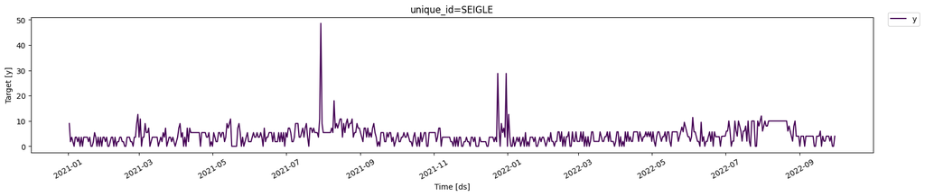

```python
plot_series(df=df, ids=['SEIGLE'], palette="viridis")
```

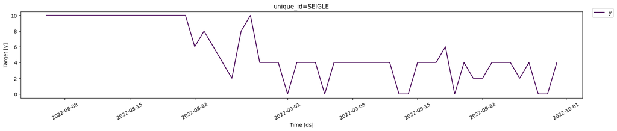

```python
plot_series(df=df, ids=["SEIGLE"], max_insample_length=56, palette="viridis")
```

The plot series function provides us the facility to zoom in to the visualization. In the later line plot we are looking at the last 56 data points which are about 2 months of data for this food item

Now, Before we proceed into forecasting, we must have something to reference to which are the **baseline models**.

### BASELINE MODELS:

```python
from statsforecast import StatsForecast
from statsforecast.models import Naive, HistoricAverage, WindowAverage, SeasonalNaive
```

```python
horizon = 7 # For how much time in furture are we looking into

models = [
    Naive(),
    HistoricAverage(),
    WindowAverage(window_size=7),
    SeasonalNaive(season_length=7)
]

sf = StatsForecast(models=models, freq="D")
sf.fit(df=df)
preds = sf.predict(h=horizon)
```

```python
preds.head(20)
```

|  | unique_id | ds | Naive | HistoricAverage | WindowAverage | SeasonalNaive |
| --- | --- | --- | --- | --- | --- | --- |
| 0 | 12 MACARON | 2022-09-29 | 10.0 | 8.974359 | 2.857143 | 0.0 |
| 1 | 12 MACARON | 2022-09-30 | 10.0 | 8.974359 | 2.857143 | 0.0 |
| 2 | 12 MACARON | 2022-10-01 | 10.0 | 8.974359 | 2.857143 | 10.0 |
| 3 | 12 MACARON | 2022-10-02 | 10.0 | 8.974359 | 2.857143 | 0.0 |
| 4 | 12 MACARON | 2022-10-03 | 10.0 | 8.974359 | 2.857143 | 0.0 |
| 5 | 12 MACARON | 2022-10-04 | 10.0 | 8.974359 | 2.857143 | 0.0 |
| 6 | 12 MACARON | 2022-10-05 | 10.0 | 8.974359 | 2.857143 | 10.0 |
| 7 | ARMORICAIN | 2022-07-22 | 5.0 | 1.500000 | NaN | NaN |
| 8 | ARMORICAIN | 2022-07-23 | 5.0 | 1.500000 | NaN | NaN |
| 9 | ARMORICAIN | 2022-07-24 | 5.0 | 1.500000 | NaN | 2.5 |
| 10 | ARMORICAIN | 2022-07-25 | 5.0 | 1.500000 | NaN | 0.0 |
| 11 | ARMORICAIN | 2022-07-26 | 5.0 | 1.500000 | NaN | 0.0 |
| 12 | ARMORICAIN | 2022-07-27 | 5.0 | 1.500000 | NaN | 0.0 |
| 13 | ARMORICAIN | 2022-07-28 | 5.0 | 1.500000 | NaN | 5.0 |
| 14 | ARTICLE 295 | 2021-11-09 | 0.0 | 0.000000 | NaN | NaN |
| 15 | ARTICLE 295 | 2021-11-10 | 0.0 | 0.000000 | NaN | NaN |
| 16 | ARTICLE 295 | 2021-11-11 | 0.0 | 0.000000 | NaN | NaN |
| 17 | ARTICLE 295 | 2021-11-12 | 0.0 | 0.000000 | NaN | NaN |
| 18 | ARTICLE 295 | 2021-11-13 | 0.0 | 0.000000 | NaN | NaN |
| 19 | ARTICLE 295 | 2021-11-14 | 0.0 | 0.000000 | NaN | NaN |

The above prediction is of 7 days for every unique product, that is the reason there are total of 1036 predictions which is (148 x 7).

```python
preds.shape
```

```
(1036, 6)
```

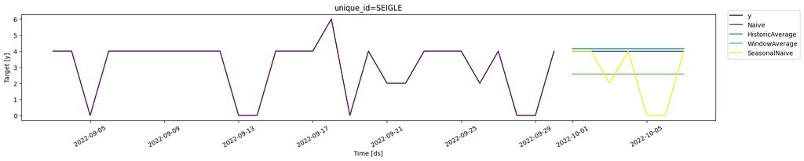

```python
plot_series(df=df,forecasts_df=preds , ids=["SEIGLE"], max_insample_length=28, palette="viridis")
```

### EVALUATE THE BASELINE MODELS

```python
test = df.groupby("unique_id").tail(7) # This is selecting last 7 days for every product.
test
```

|  | unique_id | ds | y |
| --- | --- | --- | --- |
| 71 | 12 MACARON | 2022-09-22 | 0.0 |
| 72 | 12 MACARON | 2022-09-23 | 0.0 |
| 73 | 12 MACARON | 2022-09-24 | 10.0 |
| 74 | 12 MACARON | 2022-09-25 | 0.0 |
| 75 | 12 MACARON | 2022-09-26 | 0.0 |
| ... | ... | ... | ... |
| 57041 | VIK BREAD | 2022-09-26 | 0.0 |
| 57042 | VIK BREAD | 2022-09-27 | 0.0 |
| 57043 | VIK BREAD | 2022-09-28 | 0.0 |
| 57044 | VIK BREAD | 2022-09-29 | 0.0 |
| 57045 | VIK BREAD | 2022-09-30 | 32.4 |

926 rows × 3 columns

```python
train = df.drop(test.index).reset_index(drop=True) # This removes the last 7 rows of every product
                                                  # from the data as we used it in creating test set.
train
```

|  | unique_id | ds | y |
| --- | --- | --- | --- |
| 0 | 12 MACARON | 2022-07-13 | 10.0 |
| 1 | 12 MACARON | 2022-07-14 | 0.0 |
| 2 | 12 MACARON | 2022-07-15 | 0.0 |
| 3 | 12 MACARON | 2022-07-16 | 10.0 |
| 4 | 12 MACARON | 2022-07-17 | 30.0 |
| ... | ... | ... | ... |
| 56115 | VIK BREAD | 2022-09-19 | 0.0 |
| 56116 | VIK BREAD | 2022-09-20 | 0.0 |
| 56117 | VIK BREAD | 2022-09-21 | 0.0 |
| 56118 | VIK BREAD | 2022-09-22 | 0.0 |
| 56119 | VIK BREAD | 2022-09-23 | 24.3 |

56120 rows × 3 columns

`train` is selected for training forecasting models, `test` is selected for Evaluating the model predictions.

```python
sf.fit(df=train)

preds = sf.predict(h=horizon)

eval_df = pd.merge(test, preds, 'left', ['ds', 'unique_id'])
```

```python
eval_df # We join the test set with the predictions for respective food items
```

|  | unique_id | ds | y | Naive | HistoricAverage | WindowAverage | SeasonalNaive |
| --- | --- | --- | --- | --- | --- | --- | --- |
| 0 | 12 MACARON | 2022-09-22 | 0.0 | 0.0 | 9.577465 | 1.428571 | 10.0 |
| 1 | 12 MACARON | 2022-09-23 | 0.0 | 0.0 | 9.577465 | 1.428571 | 0.0 |
| 2 | 12 MACARON | 2022-09-24 | 10.0 | 0.0 | 9.577465 | 1.428571 | 0.0 |
| 3 | 12 MACARON | 2022-09-25 | 0.0 | 0.0 | 9.577465 | 1.428571 | 0.0 |
| 4 | 12 MACARON | 2022-09-26 | 0.0 | 0.0 | 9.577465 | 1.428571 | 0.0 |
| ... | ... | ... | ... | ... | ... | ... | ... |
| 921 | VIK BREAD | 2022-09-26 | 0.0 | 24.3 | 14.590794 | 11.957143 | 0.0 |
| 922 | VIK BREAD | 2022-09-27 | 0.0 | 24.3 | 14.590794 | 11.957143 | 0.0 |
| 923 | VIK BREAD | 2022-09-28 | 0.0 | 24.3 | 14.590794 | 11.957143 | 0.0 |
| 924 | VIK BREAD | 2022-09-29 | 0.0 | 24.3 | 14.590794 | 11.957143 | 0.0 |
| 925 | VIK BREAD | 2022-09-30 | 32.4 | 24.3 | 14.590794 | 11.957143 | 24.3 |

926 rows × 7 columns

```python
evaluation = evaluate(
    eval_df,
    metrics=[mae]
)
evaluation.head(20)
```

|  | unique_id | metric | Naive | HistoricAverage | WindowAverage | SeasonalNaive |
| --- | --- | --- | --- | --- | --- | --- |
| 0 | 12 MACARON | mae | 2.857143 | 6.961771 | 3.469388 | 4.285714 |
| 1 | ARMORICAIN | mae | NaN | NaN | NaN | NaN |
| 2 | ARTICLE 295 | mae | NaN | NaN | NaN | NaN |
| 3 | BAGUETTE | mae | 17.142857 | 5.455193 | 7.877551 | 12.571429 |
| 4 | BAGUETTE APERO | mae | 0.000000 | 0.537572 | 0.642857 | 0.642857 |
| 5 | BAGUETTE GRAINE | mae | 9.800000 | 4.612271 | 2.942857 | 0.200000 |
| 6 | BANETTE | mae | 1.314286 | 5.421984 | 6.008163 | 7.885714 |
| 7 | BANETTINE | mae | 0.400000 | 0.817800 | 0.714286 | 1.000000 |
| 8 | BOISSON 33CL | mae | 5.571429 | 3.012625 | 3.091837 | 2.785714 |
| 9 | BOTTEREAU | mae | 4.571429 | 4.776190 | 4.540816 | 3.214286 |
| 10 | BOULE 200G | mae | 1.200000 | 2.943492 | 3.085714 | 3.085714 |
| 11 | BOULE 400G | mae | 6.071429 | 6.305079 | 5.932653 | 4.128571 |
| 12 | BOULE POLKA | mae | 0.257143 | 0.556916 | 0.440816 | 0.514286 |
| 13 | BRIOCHE | mae | 3.428571 | 4.493878 | 4.040816 | 9.428571 |
| 14 | BRIOCHE DE NOEL | mae | 6.000000 | 5.142857 | 5.510204 | 4.285714 |
| 15 | BRIOCHETTE | mae | 1.000000 | 1.109041 | 1.000000 | 1.000000 |
| 16 | BROWNIES | mae | 0.357143 | 0.588235 | 0.357143 | 0.357143 |
| 17 | BUCHE 4PERS | mae | NaN | NaN | NaN | NaN |
| 18 | BUCHE 6PERS | mae | NaN | NaN | NaN | NaN |
| 19 | BUCHE 8PERS | mae | NaN | NaN | NaN | NaN |

```python
# Now we check the overall model performance

evaluation = evaluation.drop(['unique_id'], axis=1).groupby('metric').mean().reset_index()
evaluation.drop(['unit_price'], axis=1, inplace=True)
```

[output not shown]

```python
evaluation
```

|  | metric | Naive | HistoricAverage | WindowAverage | SeasonalNaive |
| --- | --- | --- | --- | --- | --- |
| 0 | mae | 6.07604 | 5.253154 | 5.016269 | 4.723941 |

```python
import seaborn as sns
```

```python
methods = evaluation.columns[1:].tolist()
values = evaluation.iloc[0, 1:].tolist()
```

```python
methods,values
```

```
(['Naive', 'HistoricAverage', 'WindowAverage', 'SeasonalNaive'],
 [np.float64(6.076040494938133),
  np.float64(5.253154210003603),
  np.float64(5.016269387755102),
  np.float64(4.723940757405324)])
```

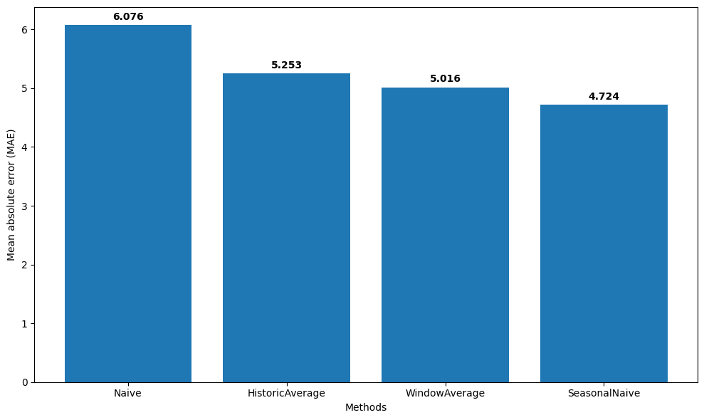

```python
plt.figure(figsize=(10, 6))
bars = plt.bar(methods, values)

for bar, value in zip(bars, values):
    plt.text(bar.get_x() + bar.get_width()/2, bar.get_height() + 0.05,
             f'{value:.3f}', ha='center', va='bottom', fontweight='bold')

plt.xlabel('Methods')
plt.ylabel('Mean absolute error (MAE)')
plt.tight_layout()
```

### **AutoARIMA**

```python
from statsforecast.models import AutoARIMA
```

```python
small_train = df.drop(test.index)
small_train = small_train[small_train['unique_id'] == "SEIGLE"]
```

```python
small_train
```

|  | unique_id | ds | y |
| --- | --- | --- | --- |
| 46547 | SEIGLE | 2021-01-02 | 9.0 |
| 46548 | SEIGLE | 2021-01-03 | 1.8 |
| 46549 | SEIGLE | 2021-01-04 | 3.6 |
| 46550 | SEIGLE | 2021-01-05 | 1.8 |
| 46551 | SEIGLE | 2021-01-06 | 0.0 |
| ... | ... | ... | ... |
| 47172 | SEIGLE | 2022-09-19 | 0.0 |
| 47173 | SEIGLE | 2022-09-20 | 4.0 |
| 47174 | SEIGLE | 2022-09-21 | 2.0 |
| 47175 | SEIGLE | 2022-09-22 | 2.0 |
| 47176 | SEIGLE | 2022-09-23 | 4.0 |

630 rows × 3 columns

```python
small_test = df[df.index.isin(test.index)]
small_test = small_test[small_test['unique_id'] == "SEIGLE"]
small_test
```

|  | unique_id | ds | y |
| --- | --- | --- | --- |
| 47177 | SEIGLE | 2022-09-24 | 4.0 |
| 47178 | SEIGLE | 2022-09-25 | 4.0 |
| 47179 | SEIGLE | 2022-09-26 | 2.0 |
| 47180 | SEIGLE | 2022-09-27 | 4.0 |
| 47181 | SEIGLE | 2022-09-28 | 0.0 |
| 47182 | SEIGLE | 2022-09-29 | 0.0 |
| 47183 | SEIGLE | 2022-09-30 | 4.0 |

```python
models = [
    AutoARIMA(seasonal=False, alias="ARIMA"),
    AutoARIMA(seasonal=True, alias="SARIMA")
]
```

```python
small_train
```

|  | unique_id | ds | y |
| --- | --- | --- | --- |
| 46547 | SEIGLE | 2021-01-02 | 9.0 |
| 46548 | SEIGLE | 2021-01-03 | 1.8 |
| 46549 | SEIGLE | 2021-01-04 | 3.6 |
| 46550 | SEIGLE | 2021-01-05 | 1.8 |
| 46551 | SEIGLE | 2021-01-06 | 0.0 |
| ... | ... | ... | ... |
| 47172 | SEIGLE | 2022-09-19 | 0.0 |
| 47173 | SEIGLE | 2022-09-20 | 4.0 |
| 47174 | SEIGLE | 2022-09-21 | 2.0 |
| 47175 | SEIGLE | 2022-09-22 | 2.0 |
| 47176 | SEIGLE | 2022-09-23 | 4.0 |

630 rows × 3 columns

```python
small_test
```

|  | unique_id | ds | y |
| --- | --- | --- | --- |
| 47177 | SEIGLE | 2022-09-24 | 4.0 |
| 47178 | SEIGLE | 2022-09-25 | 4.0 |
| 47179 | SEIGLE | 2022-09-26 | 2.0 |
| 47180 | SEIGLE | 2022-09-27 | 4.0 |
| 47181 | SEIGLE | 2022-09-28 | 0.0 |
| 47182 | SEIGLE | 2022-09-29 | 0.0 |
| 47183 | SEIGLE | 2022-09-30 | 4.0 |

```python
sf = StatsForecast(models=models, freq="D")
```

```python
sf.fit(df=small_train)
```

```
StatsForecast(models=[ARIMA,SARIMA])
```

```python
arima_preds = sf.predict(h=horizon)
```

```python
arima_eval_df = pd.merge(arima_preds, eval_df, "inner", ['ds', 'unique_id'])
arima_eval = evaluate(
    arima_eval_df,
    metrics=[mae]
)

arima_eval
```

|  | unique_id | metric | ARIMA | SARIMA | Naive | HistoricAverage | WindowAverage | SeasonalNaive |
| --- | --- | --- | --- | --- | --- | --- | --- | --- |
| 0 | SEIGLE | mae | 1.544254 | 1.544254 | 1.428571 | 1.59 | 1.55102 | 1.142857 |

```python
arima_eval = arima_eval.drop(['unique_id'], axis=1).groupby('metric').mean().reset_index()
arima_eval
```

|  | metric | ARIMA | SARIMA | Naive | HistoricAverage | WindowAverage | SeasonalNaive |
| --- | --- | --- | --- | --- | --- | --- | --- |
| 0 | mae | 1.544254 | 1.544254 | 1.428571 | 1.59 | 1.55102 | 1.142857 |

The above step is useful when we predict for more than one food products of the bakery.

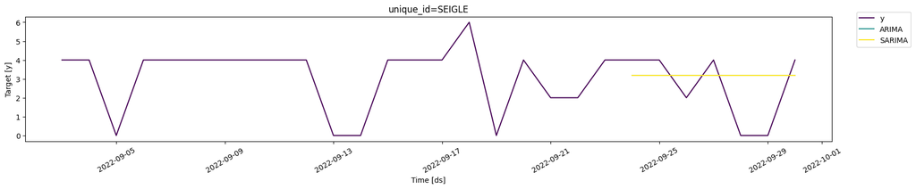

```python
plot_series(
    df=df,
    forecasts_df=arima_preds,
    ids=['SEIGLE'],
    max_insample_length=28,
    palette="viridis"
)
```

The prediction line overlaps totally.

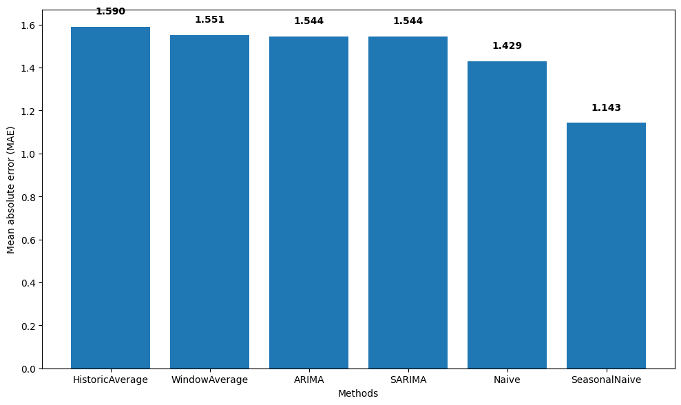

```python
methods = arima_eval.columns[1:].tolist()
values = arima_eval.iloc[0, 1:].tolist()

sorted_data = sorted(zip(methods, values), key=lambda x: x[1], reverse=True)
methods_sorted, values_sorted = zip(*sorted_data)

plt.figure(figsize=(10, 6))
bars = plt.bar(methods_sorted, values_sorted)

for bar, value in zip(bars, values_sorted):
    plt.text(bar.get_x() + bar.get_width()/2, bar.get_height() + 0.05,
             f'{value:.3f}', ha='center', va='bottom', fontweight='bold')

plt.xlabel('Methods')
plt.ylabel('Mean absolute error (MAE)')
plt.tight_layout()

plt.show()
```

Seasonal Naive is actually performing better in this situation.

### Cross-Validation

```python
small_df = df[df['unique_id'] == "SEIGLE"]

models = [
    SeasonalNaive(season_length=7),
    AutoARIMA(seasonal=False, alias="ARIMA"),
    AutoARIMA(season_length=7, alias='SARIMA')
]
```

```python
sf =StatsForecast(models=models, freq="D")
cv_df = sf.cross_validation(
    h=horizon,
    df=small_df,
    n_windows=8,
    step_size=horizon,
    refit=True
)
```

```python
cv_df.head()
```

|  | unique_id | ds | cutoff | y | SeasonalNaive | ARIMA | SARIMA |
| --- | --- | --- | --- | --- | --- | --- | --- |
| 0 | SEIGLE | 2022-08-06 | 2022-08-05 | 10.0 | 10.0 | 6.724055 | 7.240115 |
| 1 | SEIGLE | 2022-08-07 | 2022-08-05 | 10.0 | 12.0 | 6.631092 | 6.827595 |
| 2 | SEIGLE | 2022-08-08 | 2022-08-05 | 10.0 | 6.0 | 6.541441 | 5.318977 |
| 3 | SEIGLE | 2022-08-09 | 2022-08-05 | 10.0 | 8.0 | 6.454983 | 4.703045 |
| 4 | SEIGLE | 2022-08-10 | 2022-08-05 | 10.0 | 10.0 | 6.371604 | 5.338128 |

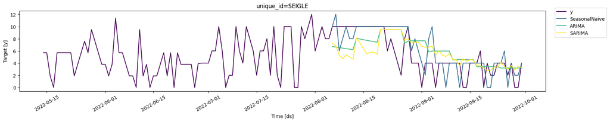

```python
plot_series(
    df=small_df,
    forecasts_df=cv_df.drop(['y', 'cutoff'], axis=1),
    ids=["SEIGLE"],
    max_insample_length=140,
    palette="viridis"
)
```

```python
cv_eval = evaluate(
    cv_df.drop(['cutoff'], axis=1),
    metrics=[mae],
)

cv_eval = cv_eval.drop(['unique_id'], axis=1).groupby('metric').mean().reset_index()
cv_eval
```

|  | metric | SeasonalNaive | ARIMA | SARIMA |
| --- | --- | --- | --- | --- |
| 0 | mae | 1.857143 | 2.491199 | 2.64591 |

[figure not shown]

```python
methods = cv_eval.columns[1:].tolist()
values = cv_eval.iloc[0,1:].tolist()

plt.figure(figsize=(10, 6))
bars = plt.bar(methods, values)

for bar, value in zip(bars, values_sorted):
    plt.text(bar.get_x() + bar.get_width()/2, bar.get_height() + 0.05,
             f'{value:.3f}', ha='center', va='bottom', fontweight='bold')

plt.xlabel('Methods')
plt.ylabel('Mean absolute error (MAE)')
plt.tight_layout()

plt.show()
```

### Forecasting with exogenous features

```python
df = pd.read_csv("daily_sales_french_bakery.csv", parse_dates=['ds'])
df = df.groupby('unique_id').filter(lambda x: len(x) >= 28)
df.head()
```

|  | unique_id | ds | y | unit_price |
| --- | --- | --- | --- | --- |
| 0 | 12 MACARON | 2022-07-13 | 10.0 | 10.0 |
| 1 | 12 MACARON | 2022-07-14 | 0.0 | 10.0 |
| 2 | 12 MACARON | 2022-07-15 | 0.0 | 10.0 |
| 3 | 12 MACARON | 2022-07-16 | 10.0 | 10.0 |
| 4 | 12 MACARON | 2022-07-17 | 30.0 | 10.0 |

```python
df.shape
```

```
(56904, 4)
```

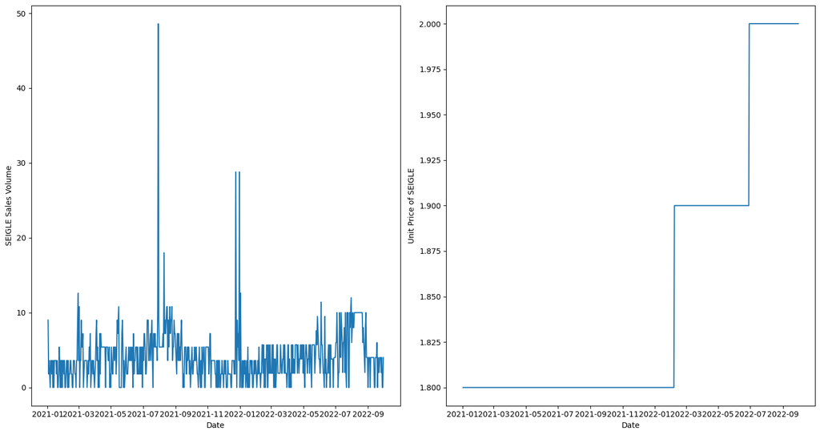

```python
seigle_plot_df = df[df['unique_id'] == "SEIGLE"]

fig, (ax1, ax2) = plt.subplots(nrows=1, ncols=2, figsize=(15,8))

ax1.plot(seigle_plot_df['ds'], seigle_plot_df['y'])
ax1.set_xlabel("Date")
ax1.set_ylabel("SEIGLE Sales Volume")

ax2.plot(seigle_plot_df['ds'], seigle_plot_df['unit_price'])
ax2.set_xlabel("Date")
ax2.set_ylabel("Unit Price of SEIGLE")

plt.tight_layout()
```

```python
small_df = df[df['unique_id'] == "SEIGLE"]

test = small_df.groupby("unique_id").tail(7)
train = small_df.drop(test.index).reset_index(drop=True)
```

```python
futr_exog_df = test.drop(['y'], axis=1)
futr_exog_df.head()
```

|  | unique_id | ds | unit_price |
| --- | --- | --- | --- |
| 47177 | SEIGLE | 2022-09-24 | 2.0 |
| 47178 | SEIGLE | 2022-09-25 | 2.0 |
| 47179 | SEIGLE | 2022-09-26 | 2.0 |
| 47180 | SEIGLE | 2022-09-27 | 2.0 |
| 47181 | SEIGLE | 2022-09-28 | 2.0 |

```python
models = [
    AutoARIMA(season_length=7, alias="SARIMA_exog")
]

sf = StatsForecast(models=models, freq="D")
sf.fit(df=train)
arima_exog_preds = sf.predict(h=7, X_df=futr_exog_df)

models = [
    AutoARIMA(season_length=7, alias="SARIMA")
]

sf = StatsForecast(models=models, freq="D")
sf.fit(df=train.drop(["unit_price"], axis=1))
arima_preds = sf.predict(h=horizon)
```

```python
test_df = test.merge(arima_exog_preds, on=["unique_id", "ds"], how="left")\
              .merge(arima_preds, on=["unique_id", "ds"], how="left")
test_df
```

|  | unique_id | ds | y | unit_price | SARIMA_exog | SARIMA |
| --- | --- | --- | --- | --- | --- | --- |
| 0 | SEIGLE | 2022-09-24 | 4.0 | 2.0 | 4.704053 | 4.089293 |
| 1 | SEIGLE | 2022-09-25 | 4.0 | 2.0 | 5.460237 | 3.475758 |
| 2 | SEIGLE | 2022-09-26 | 2.0 | 2.0 | 3.608523 | 2.915617 |
| 3 | SEIGLE | 2022-09-27 | 4.0 | 2.0 | 4.407201 | 3.626774 |
| 4 | SEIGLE | 2022-09-28 | 0.0 | 2.0 | 4.034833 | 2.873250 |
| 5 | SEIGLE | 2022-09-29 | 0.0 | 2.0 | 4.042378 | 3.460413 |
| 6 | SEIGLE | 2022-09-30 | 4.0 | 2.0 | 4.482354 | 3.262472 |

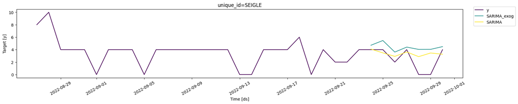

```python
plot_series(
    df=train,
    forecasts_df=test_df,
    ids=["SEIGLE"],
    max_insample_length=28,
    models=["SARIMA_exog", "SARIMA"],
    palette="viridis"
)
```

```python
models = [
    AutoARIMA(season_length=7, alias="SARIMA_exog")
]

sf = StatsForecast(models=models, freq="D")
cv_exog_df = sf.cross_validation(
    h=horizon, # 7 days
    df=small_df,
    n_windows=8,
    step_size=7,
    refit=True
)

cv_exog_df.head()
```

|  | unique_id | ds | cutoff | y | SARIMA_exog |
| --- | --- | --- | --- | --- | --- |
| 0 | SEIGLE | 2022-08-06 | 2022-08-05 | 10.0 | 7.374281 |
| 1 | SEIGLE | 2022-08-07 | 2022-08-05 | 10.0 | 6.979281 |
| 2 | SEIGLE | 2022-08-08 | 2022-08-05 | 10.0 | 5.499561 |
| 3 | SEIGLE | 2022-08-09 | 2022-08-05 | 10.0 | 4.895369 |
| 4 | SEIGLE | 2022-08-10 | 2022-08-05 | 10.0 | 5.527649 |

```python
cv_exog_eval = evaluate(
    cv_exog_df.drop(["cutoff"], axis=1),
    metrics=[mae],
)
cv_exog_eval = cv_exog_eval.drop(['unique_id'], axis=1).groupby('metric').mean().reset_index()
cv_exog_eval
```

|  | metric | SARIMA_exog |
| --- | --- | --- |
| 0 | mae | 2.794909 |